# TP9 : Visualiser des données avec ggplot2

Rémi Pierron

2026-11-24

# Partie A

## A1

### a. Une première courbe

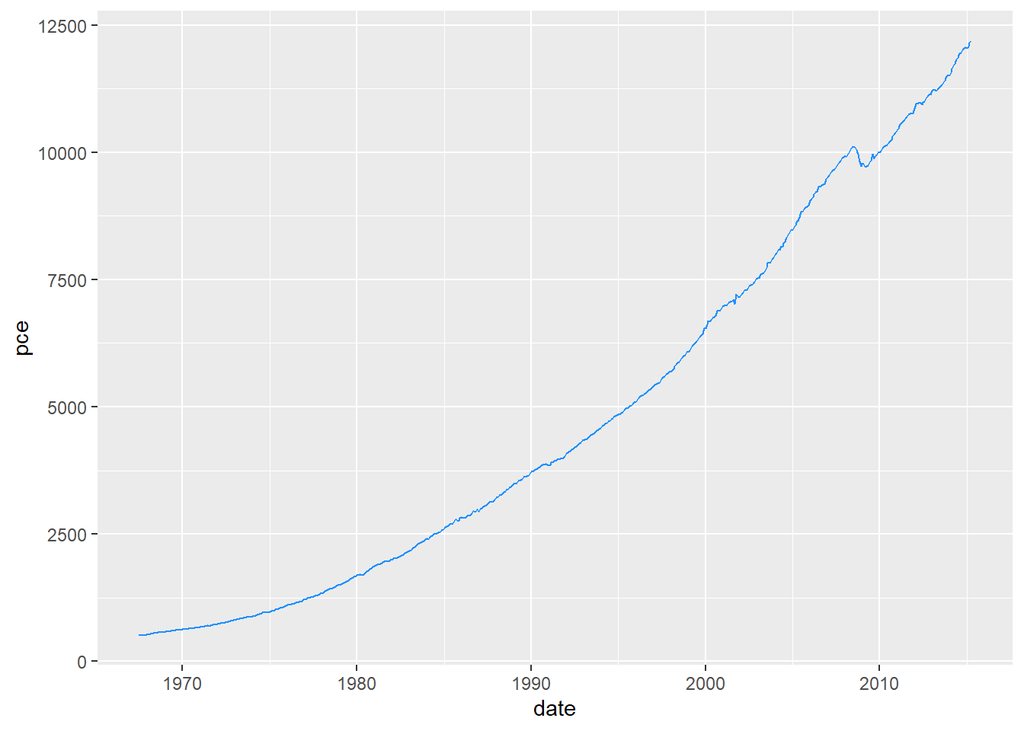

```r
p_1 <- ggplot(economics, aes(x = date, y = pce)) +
  geom_line(colour = "dodgerblue", linewidth = 0.5)
p_1
```

### b. Titre

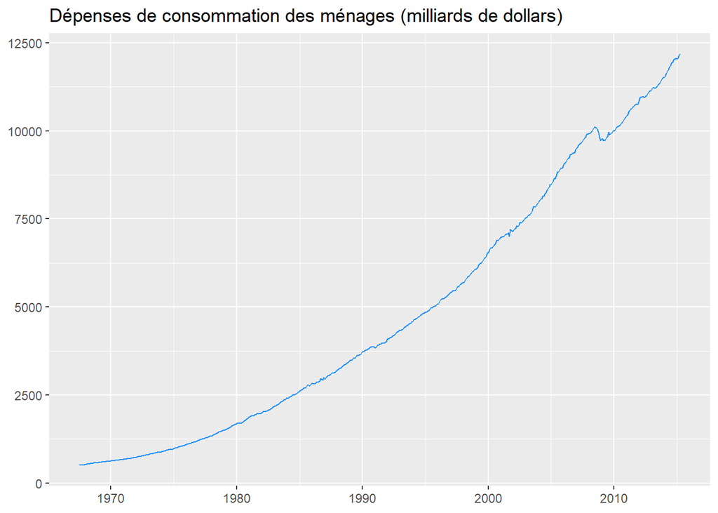

```r
p_1 <- p_1 +
  labs(title = "Dépenses de consommation des ménages (milliards de dollars)",
       x = NULL, y = NULL)
p_1
```

### c. Graduations

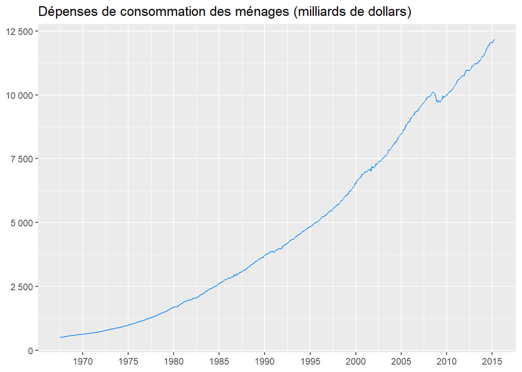

```r
p_1 <- p_1 +
  scale_x_date(date_breaks = "5 years", date_labels = "%Y") +
  scale_y_continuous(labels = scales::label_number(big.mark = " "))
p_1
```

### d. Échelle logarithmique

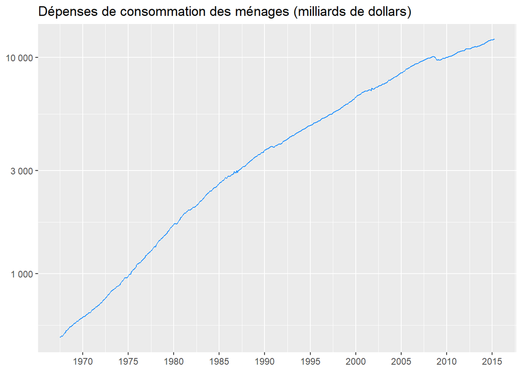

```r
p_1 +
  scale_y_log10(labels = scales::label_number(big.mark = " "))
```

Sur l’échelle linéaire, la courbe semble s’accélérer : les dépenses passent d’environ 500 à plus de 12 000 milliards de dollars, mais une même hausse en milliards ne représente pas la même croissance en 1970 et en 2010. Sur une échelle logarithmique, une pente constante correspond à un taux de croissance constant : on peut donc juger de la régularité de la croissance. On voit ainsi que la croissance n’est pas régulière : elle est forte dans les années 1970 (environ 10 % par an, inflation comprise), puis ralentit progressivement (environ 4 % par an dans les années 2000-2010), avec une baisse visible en 2008-2009 pendant la crise financière.

## A2

### a. Format long

```r
df <- economics |>
  select(date, psavert, uempmed) |>
  pivot_longer(c(psavert, uempmed), names_to = "serie", values_to = "valeur")
df
```

```
## # A tibble: 1,148 × 3
##    date       serie   valeur
##    <date>     <chr>    <dbl>
##  1 1967-07-01 psavert   12.6
##  2 1967-07-01 uempmed    4.5
##  3 1967-08-01 psavert   12.6
##  4 1967-08-01 uempmed    4.7
##  5 1967-09-01 psavert   11.9
##  6 1967-09-01 uempmed    4.6
##  7 1967-10-01 psavert   12.9
##  8 1967-10-01 uempmed    4.9
##  9 1967-11-01 psavert   12.8
## 10 1967-11-01 uempmed    4.7
## # ℹ 1,138 more rows
```

Ce format est adapté à `ggplot2` car chaque esthétique correspond à une colonne : la variable `serie` peut être associée directement à la couleur ou au type de ligne, et `ggplot2` construit automatiquement une courbe par série et la légende correspondante, avec un seul `geom_line()`.

### b. Deux séries

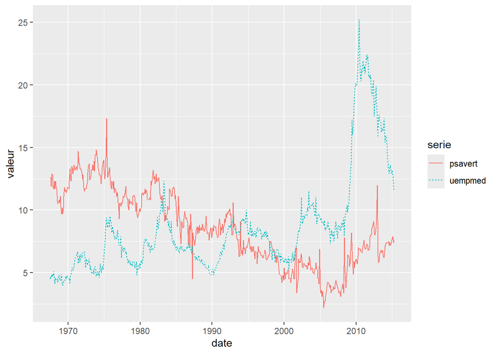

```r
ggplot(df, aes(x = date, y = valeur, colour = serie, linetype = serie)) +
  geom_line()
```

### c. Couleurs, types de ligne et légende

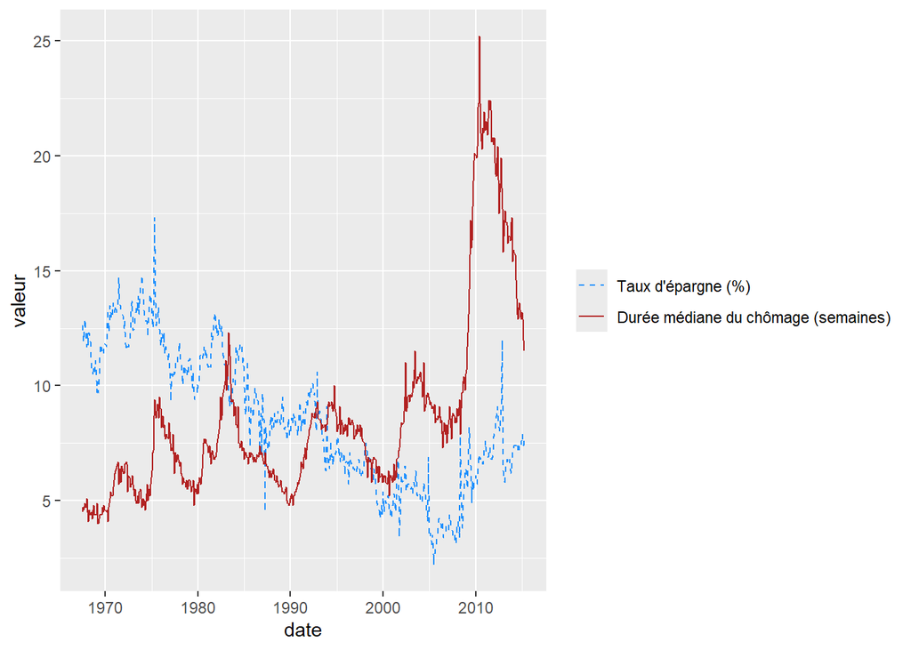

```r
etiquettes <- c(psavert = "Taux d'épargne (%)",
                uempmed = "Durée médiane du chômage (semaines)")

p_2 <- ggplot(df, aes(x = date, y = valeur, colour = serie, linetype = serie)) +
  geom_line() +
  scale_colour_manual(values = c(psavert = "dodgerblue", uempmed = "firebrick"),
                      labels = etiquettes, name = NULL) +
  scale_linetype_manual(values = c(psavert = "dashed", uempmed = "solid"),
                        labels = etiquettes, name = NULL)
p_2
```

Les deux échelles (couleur et type de ligne) ont le même nom (`NULL`) et les mêmes étiquettes : `ggplot2` les fusionne en une seule légende.

### d. Légende sous le graphique et thème

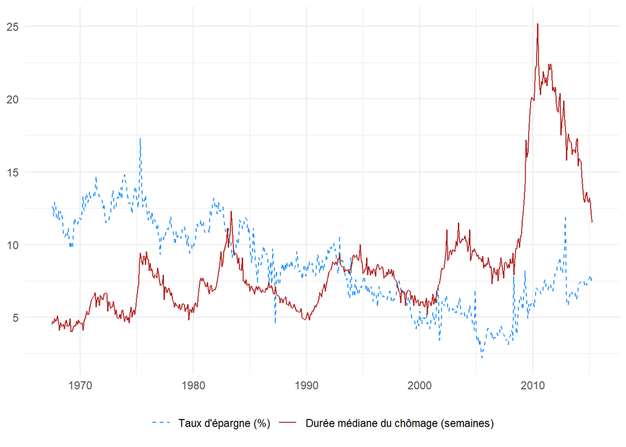

```r
p_2 <- p_2 +
  labs(x = NULL, y = NULL) +
  theme_minimal() +
  theme(legend.position = "bottom")
p_2
```

## A3

### a. Maximum du taux d’épargne

```r
max_epargne <- economics |> slice_max(psavert, n = 1)
max_epargne
```

```
## # A tibble: 1 × 6
##   date         pce    pop psavert uempmed unemploy
##   <date>     <dbl>  <dbl>   <dbl>   <dbl>    <dbl>
## 1 1975-05-01 1019. 215523    17.3     9.4     8433
```

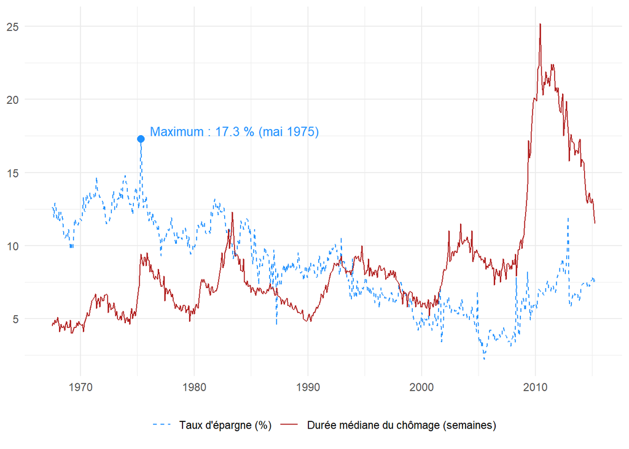

```r
p_3 <- p_2 +
  annotate("point", x = max_epargne$date, y = max_epargne$psavert,
           colour = "dodgerblue", size = 2.5) +
  annotate("text", x = max_epargne$date, y = max_epargne$psavert,
           label = paste0("Maximum : ", max_epargne$psavert, " % (",
                          format(max_epargne$date, "%B %Y"), ")"),
           hjust = -0.05, vjust = -0.3, size = 3.5, colour = "dodgerblue")
p_3
```

Le maximum historique du taux d’épargne, 17.3 %, est atteint en mai 1975.

### b. Récessions

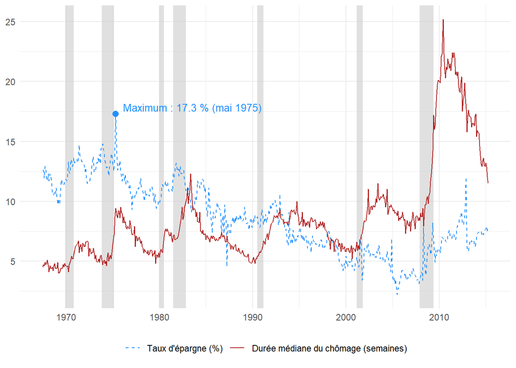

```r
recessions <- tibble(
  debut = as.Date(c("1969-12-01", "1973-11-01", "1980-01-01", "1981-07-01",
                    "1990-07-01", "2001-03-01", "2007-12-01")),
  fin   = as.Date(c("1970-11-01", "1975-03-01", "1980-07-01", "1982-11-01",
                    "1991-03-01", "2001-11-01", "2009-06-01")))

# Les bandes sont ajoutées en première couche pour être sous les courbes
p_3$layers <- c(
  geom_rect(data = recessions,
            aes(xmin = debut, xmax = fin, ymin = -Inf, ymax = Inf),
            inherit.aes = FALSE, fill = "grey80", alpha = 0.6),
  p_3$layers
)
p_3
```

### c. Chômage et récessions

Pendant chaque récession, et surtout dans les mois qui suivent, la durée médiane du chômage augmente nettement : elle atteint son pic avec un décalage d’un à deux ans après le début de la récession (par exemple 12,3 semaines en mai 1983 après la récession de 1981-1982), puis redescend lentement. La récession de 2007-2009 a eu l’effet de loin le plus marqué : la durée médiane passe d’environ 8 semaines fin 2007 à plus de 25 semaines en 2010, un niveau jamais atteint auparavant, et elle reste élevée bien après la fin officielle de la récession.

## A4

### a. Cinq séries en facettes

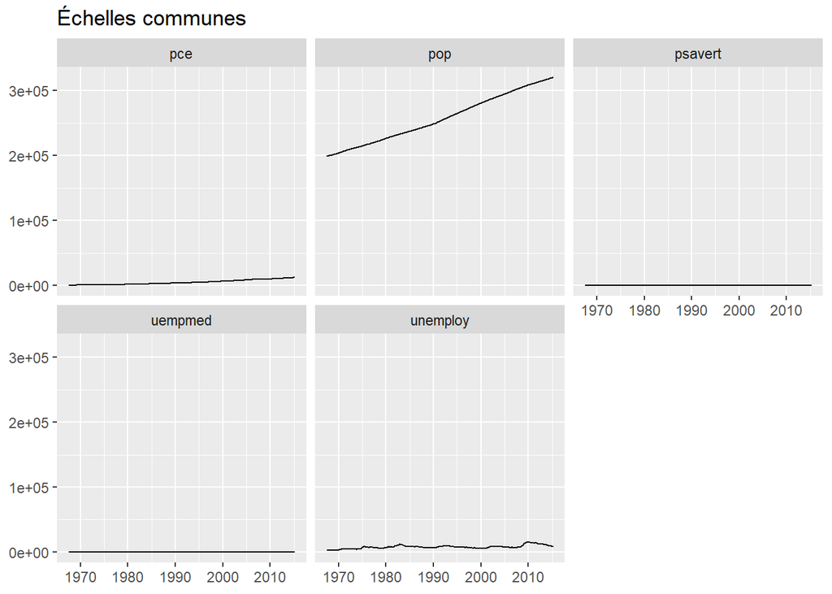

```r
eco_long <- economics |>
  pivot_longer(-date, names_to = "serie", values_to = "valeur")

ggplot(eco_long, aes(x = date, y = valeur)) +
  geom_line() +
  facet_wrap(vars(serie)) +
  labs(x = NULL, y = NULL, title = "Échelles communes")
```

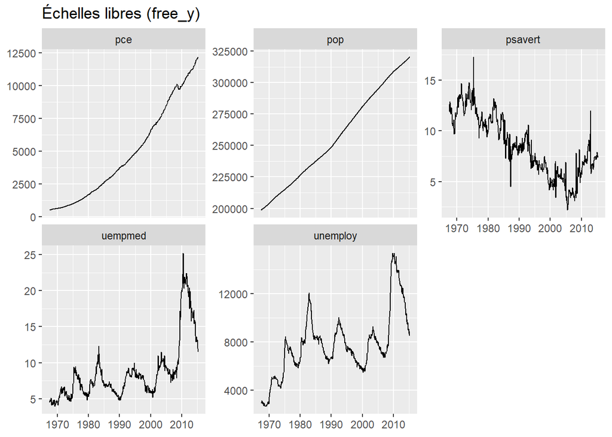

```r
ggplot(eco_long, aes(x = date, y = valeur)) +
  geom_line() +
  facet_wrap(vars(serie), scales = "free_y") +
  labs(x = NULL, y = NULL, title = "Échelles libres (free_y)")
```

Seul le second graphique est lisible. Les séries ont des ordres de grandeur très différents : la population (`pop`) dépasse 300 000 milliers, alors que le taux d’épargne et la durée du chômage sont de l’ordre de 10. Avec une échelle commune, toutes les séries sauf `pop` sont écrasées sur une ligne plate près de zéro. Avec `scales = "free_y"`, chaque panneau a sa propre échelle verticale et on voit l’évolution de chaque série.

### b. Titres en français, une colonne

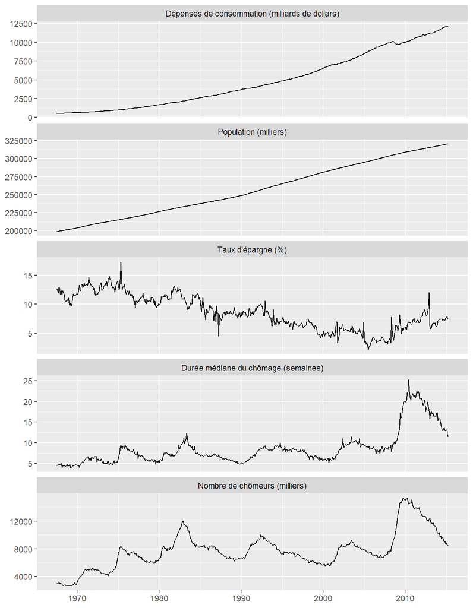

```r
noms_series <- c(
  pce      = "Dépenses de consommation (milliards de dollars)",
  pop      = "Population (milliers)",
  psavert  = "Taux d'épargne (%)",
  uempmed  = "Durée médiane du chômage (semaines)",
  unemploy = "Nombre de chômeurs (milliers)"
)

ggplot(eco_long, aes(x = date, y = valeur)) +
  geom_line() +
  facet_wrap(vars(serie), ncol = 1, scales = "free_y",
             labeller = as_labeller(noms_series)) +
  labs(x = NULL, y = NULL)
```

## A5

### a. Taux de chômage et variation sur un an

```r
economics <- economics |>
  mutate(u_rate  = unemploy / pop,
         var_1an = 100 * (u_rate - lag(u_rate, 12)))
```

### b. Barres colorées

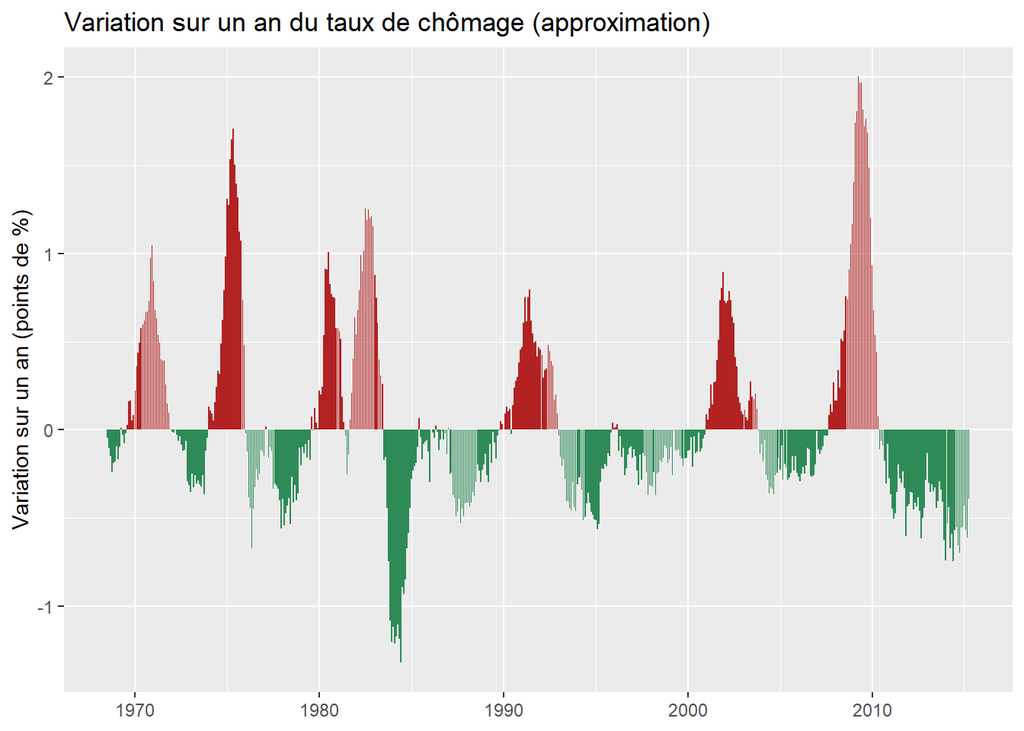

```r
p_var <- economics |>
  filter(!is.na(var_1an)) |>
  ggplot(aes(x = date, y = var_1an, fill = var_1an > 0)) +
  geom_col() +
  scale_fill_manual(values = c(`TRUE` = "firebrick", `FALSE` = "seagreen"),
                    guide = "none") +
  labs(x = NULL,
       y = "Variation sur un an (points de %)",
       title = "Variation sur un an du taux de chômage (approximation)")
p_var
```

En rouge, les mois où le chômage a augmenté sur un an ; en vert, ceux où il a diminué.

### c. Zoom sur 2007-2012

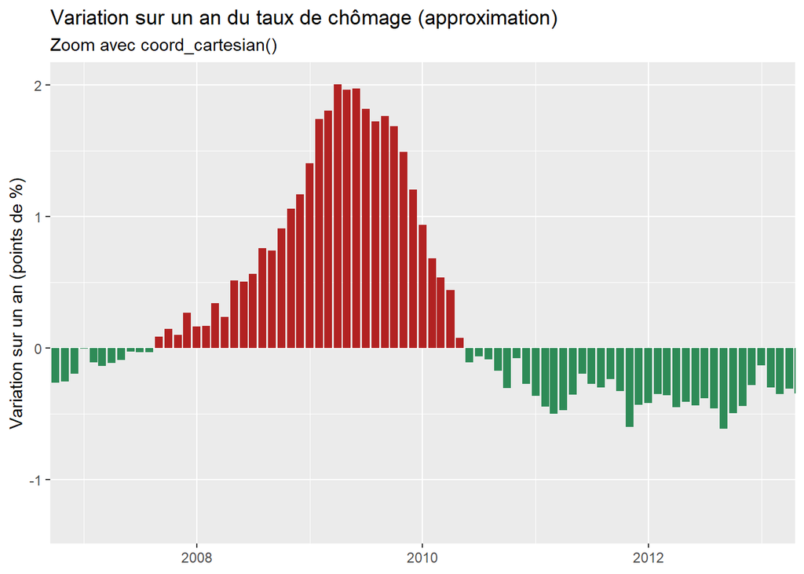

```r
limites <- as.Date(c("2007-01-01", "2012-12-31"))

p_var + coord_cartesian(xlim = limites) +
  labs(subtitle = "Zoom avec coord_cartesian()")
```

```r
p_var + scale_x_date(limits = limites) +
  labs(subtitle = "Zoom avec scale_x_date(limits = …)")
```

```
## Warning: Removed 491 rows containing missing values or values outside the scale range
## (`geom_col()`).
```

[figure not shown]

Avec `coord_cartesian()`, aucun message n’est affiché : le graphique est simplement recadré, toutes les données sont conservées. Avec `scale_x_date(limits = …)`, `ggplot2` affiche un avertissement (« Removed … rows ») : les observations hors des limites sont supprimées avant le tracé (et les barres situées aux bords de l’intervalle peuvent disparaître). Ici l’effet visuel est faible, mais pour une courbe lissée, une boîte à moustaches ou un calcul statistique, le résultat serait modifié. Pour zoomer, il faut donc utiliser `coord_cartesian()`.

## A6

```r
dir.create("sorties", showWarnings = FALSE)

ggsave("sorties/p_3.pdf", p_3, width = 18, height = 10, units = "cm")
ggsave("sorties/p_3.png", p_3, width = 16, height = 9, units = "cm", dpi = 300)
ggsave("sorties/p_3_grand.png", p_3, width = 32, height = 18, units = "cm", dpi = 300)

list.files("sorties")
```

```
## [1] "p_3.pdf"       "p_3.png"       "p_3_grand.png"
```

En 16 × 9 cm, les textes sont lisibles mais occupent une place importante : la légende, longue, est serrée sous le graphique et peut même être coupée à droite. En 32 × 18 cm, la taille des textes (fixée en points, donc en unité physique) ne change pas alors que la surface double dans chaque dimension : les textes paraissent minuscules par rapport au graphique. Pour obtenir un grand PNG lisible, il faut garder une taille physique raisonnable (par exemple 16 × 9 cm) et augmenter la résolution (`dpi = 600`) : le nombre de pixels augmente sans que les proportions changent. On peut aussi agrandir les textes (`theme(base_size = …)`) ou utiliser l’argument `scale` de `ggsave()`.

# Partie B

## B1

### a. Importer et explorer

```r
ble <- read_delim("data/ble_anova2.csv", delim = ";", show_col_types = FALSE) |>
  mutate(variete = factor(variete),
         phyto   = factor(phyto))
ble
```

```
## # A tibble: 80 × 4
##    parcelle variete phyto   rdt
##       <dbl> <fct>   <fct> <dbl>
##  1        1 V1      Avec   5652
##  2        2 V1      Avec   5583
##  3        3 V1      Avec   5612
##  4        4 V1      Avec   5735
##  5        5 V1      Avec   5704
##  6        6 V1      Avec   5544
##  7        7 V1      Avec   5563
##  8        8 V1      Avec   5610
##  9        9 V1      Avec   5641
## 10       10 V1      Avec   5637
## # ℹ 70 more rows
```

```r
count(ble, variete, phyto)
```

```
## # A tibble: 8 × 3
##   variete phyto     n
##   <fct>   <fct> <int>
## 1 V1      Avec     10
## 2 V1      Sans     10
## 3 V2      Avec     10
## 4 V2      Sans     10
## 5 V3      Avec     10
## 6 V3      Sans     10
## 7 V4      Avec     10
## 8 V4      Sans     10
```

Chaque combinaison variété × traitement compte 10 parcelles : le plan d’expérience est équilibré (4 × 2 × 10 = 80 parcelles).

### b. Boîtes à moustaches par variété

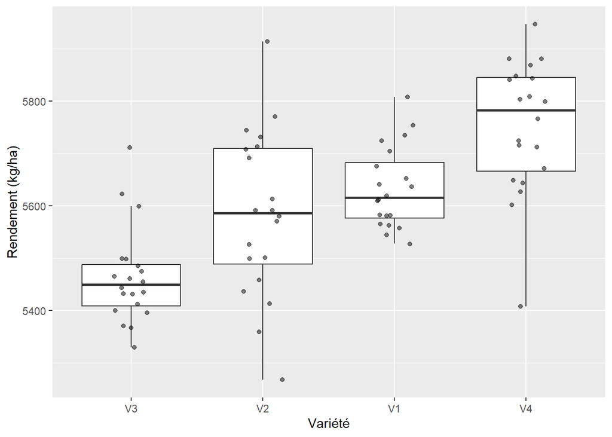

```r
ggplot(ble, aes(x = fct_reorder(variete, rdt, .fun = median), y = rdt)) +
  geom_boxplot(outlier.shape = NA) +
  geom_jitter(width = 0.15, alpha = 0.5) +
  labs(x = "Variété", y = "Rendement (kg/ha)")
```

Les variétés sont triées par rendement médian croissant : V3 a les rendements les plus faibles (médiane d’environ 5 450 kg/ha) et V4 les plus élevés (environ 5 780 kg/ha). V2 est la variété la plus dispersée.

`outlier.shape = NA` évite d’afficher deux fois les valeurs extrêmes, puisque toutes les observations sont déjà superposées.

## B2

### a. Boîtes côte à côte

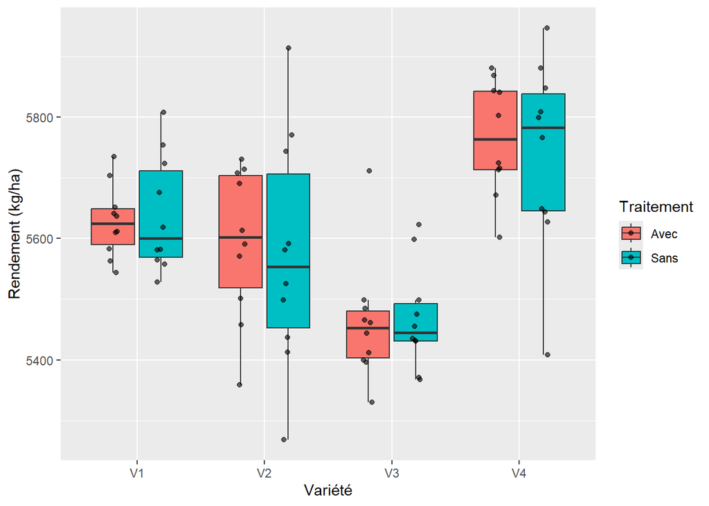

```r
ggplot(ble, aes(x = variete, y = rdt, fill = phyto)) +
  geom_boxplot(outlier.shape = NA) +
  geom_point(position = position_jitterdodge(jitter.width = 0.15),
             alpha = 0.6) +
  labs(x = "Variété", y = "Rendement (kg/ha)", fill = "Traitement")
```

### b. Avec des facettes

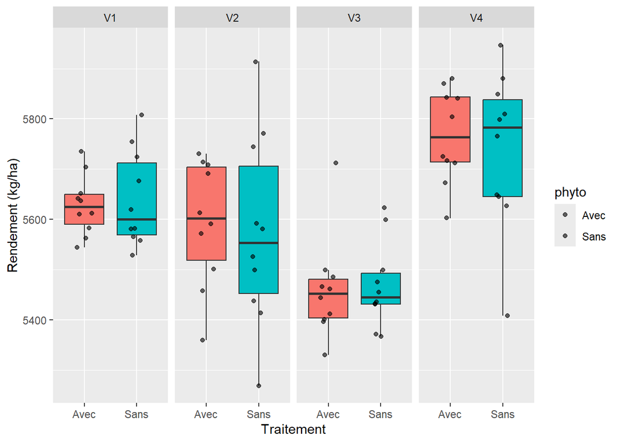

```r
ggplot(ble, aes(x = phyto, y = rdt, fill = phyto)) +
  geom_boxplot(outlier.shape = NA, show.legend = FALSE) +
  geom_jitter(width = 0.15, alpha = 0.6) +
  facet_wrap(vars(variete), nrow = 1) +
  labs(x = "Traitement", y = "Rendement (kg/ha)")
```

Les deux graphiques permettent les deux comparaisons, mais pas avec la même facilité. Avec les facettes, les deux boîtes d’une même variété sont isolées dans leur panneau : la comparaison avec et sans traitement est immédiate, alors que comparer les variétés demande de passer d’un panneau à l’autre. Avec les boîtes côte à côte, les quatre variétés sont alignées sur un même axe horizontal : c’est la comparaison entre variétés qui est la plus facile. Ici, les deux graphiques montrent que l’écart entre variétés est bien plus marqué que l’écart dû au traitement.

## B3

### a. Moyennes et intervalles de confiance

```r
resume_ble <- ble |>
  group_by(variete, phyto) |>
  summarise(moyenne    = mean(rdt),
            ecart_type = sd(rdt),
            n          = n(),
            .groups    = "drop") |>
  mutate(demi_ic = qt(0.975, df = n - 1) * ecart_type / sqrt(n),
         ic_bas  = moyenne - demi_ic,
         ic_haut = moyenne + demi_ic)
resume_ble
```

```
## # A tibble: 8 × 8
##   variete phyto moyenne ecart_type     n demi_ic ic_bas ic_haut
##   <fct>   <fct>   <dbl>      <dbl> <int>   <dbl>  <dbl>   <dbl>
## 1 V1      Avec    5628.       59.6    10    42.6  5585.   5671.
## 2 V1      Sans    5640.       95.3    10    68.2  5571.   5708.
## 3 V2      Avec    5594.      124.     10    88.9  5505.   5683.
## 4 V2      Sans    5574.      191.     10   137.   5438.   5711.
## 5 V3      Avec    5460.      102.     10    72.7  5388.   5533.
## 6 V3      Sans    5469.       85.5    10    61.1  5408.   5530.
## 7 V4      Avec    5767.       94.1    10    67.3  5699.   5834.
## 8 V4      Sans    5738.      158.     10   113.   5625.   5851.
```

### b. `geom_pointrange()`

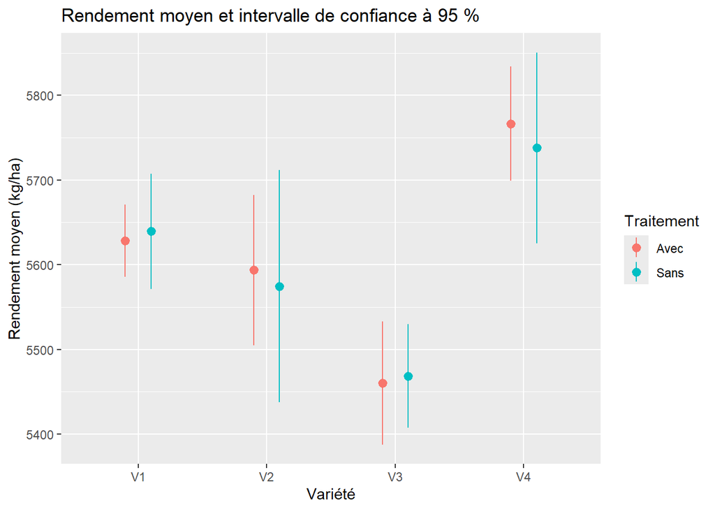

```r
decalage <- position_dodge(width = 0.4)

ggplot(resume_ble, aes(x = variete, y = moyenne, colour = phyto)) +
  geom_pointrange(aes(ymin = ic_bas, ymax = ic_haut), position = decalage) +
  labs(x = "Variété", y = "Rendement moyen (kg/ha)", colour = "Traitement",
       title = "Rendement moyen et intervalle de confiance à 95 %")
```

### c. Avec `stat_summary()`

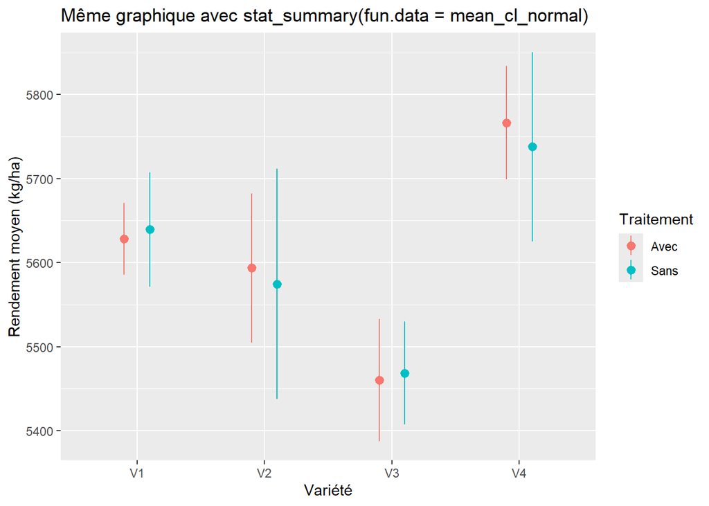

```r
ggplot(ble, aes(x = variete, y = rdt, colour = phyto)) +
  stat_summary(fun.data = mean_cl_normal, geom = "pointrange",
               position = decalage) +
  labs(x = "Variété", y = "Rendement moyen (kg/ha)", colour = "Traitement",
       title = "Même graphique avec stat_summary(fun.data = mean_cl_normal)")
```

```r
# Vérification numérique : mean_cl_normal() utilise aussi la loi de Student
verif <- ble |>
  group_by(variete, phyto) |>
  summarise(Hmisc::smean.cl.normal(rdt) |> as.list() |> as_tibble(),
            .groups = "drop") |>
  left_join(resume_ble, by = c("variete", "phyto"))

all.equal(verif$Lower, verif$ic_bas)
```

```
## [1] TRUE
```

```r
all.equal(verif$Upper, verif$ic_haut)
```

```
## [1] TRUE
```

Les deux graphiques sont identiques et la comparaison numérique renvoie `TRUE` : `mean_cl_normal()` calcule le même intervalle de Student à 95 % que notre calcul manuel.

## B4

### a. Graphiques d’interaction

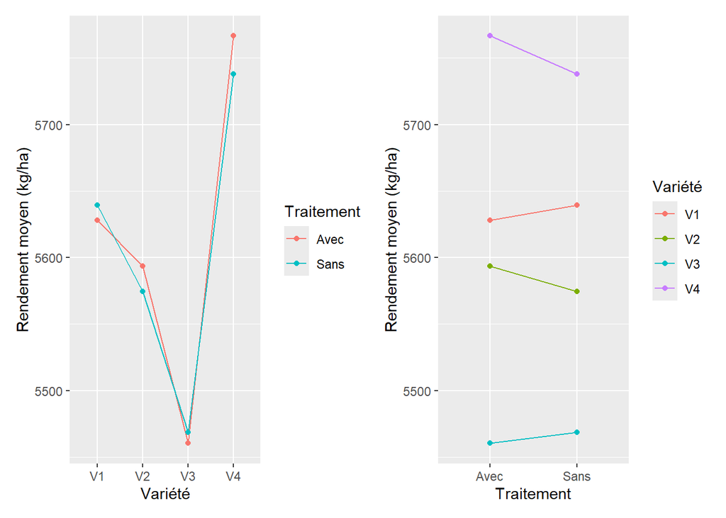

```r
p_inter_1 <- ggplot(resume_ble, aes(x = variete, y = moyenne, colour = phyto)) +
  geom_line(aes(group = phyto)) +
  geom_point() +
  labs(x = "Variété", y = "Rendement moyen (kg/ha)", colour = "Traitement")

p_inter_2 <- ggplot(resume_ble, aes(x = phyto, y = moyenne, colour = variete)) +
  geom_line(aes(group = variete)) +
  geom_point() +
  labs(x = "Traitement", y = "Rendement moyen (kg/ha)", colour = "Variété")

p_inter_1 + p_inter_2
```

### b. Interprétation

Les lignes ne sont pas parfaitement parallèles : sur le premier graphique, les deux courbes se croisent (le traitement est légèrement favorable pour V2 et V4, légèrement défavorable pour V1 et V3). Mais ces écarts sont minimes (entre 10 et 30 kg/ha environ), bien plus petits que la largeur des intervalles de confiance vus en B3 : on ne peut pas conclure à une interaction. Sur le second graphique, les lignes sont presque horizontales : le traitement ne change pratiquement pas le rendement (5 612 kg/ha en moyenne avec, 5 605 sans). Le traitement phytosanitaire n’a donc pas d’intérêt visible sur le rendement dans cet essai, quelle que soit la variété ; c’est le choix de la variété qui compte.

## B5

### a. Barres avec un axe qui commence à 0

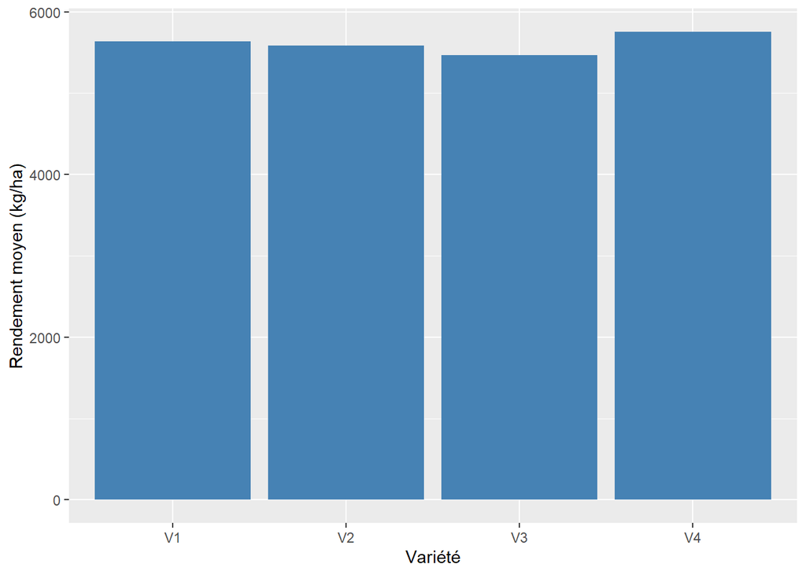

```r
moy_variete <- ble |>
  group_by(variete) |>
  summarise(moyenne = mean(rdt))

p_barres <- ggplot(moy_variete, aes(x = variete, y = moyenne)) +
  geom_col(fill = "steelblue") +
  labs(x = "Variété", y = "Rendement moyen (kg/ha)")
p_barres
```

### b. Zoom sur 5 400 – 5 800 kg/ha

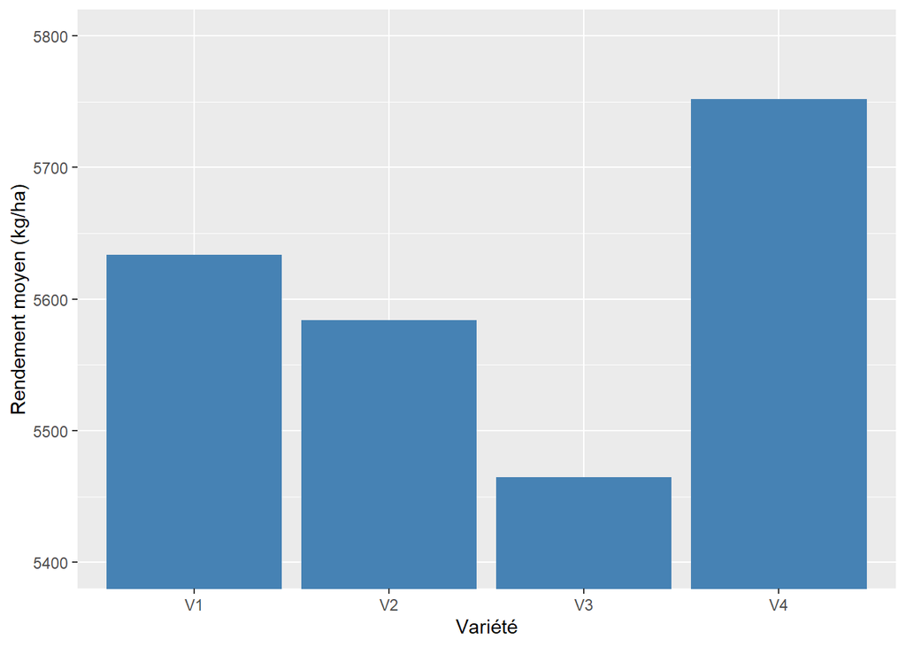

```r
p_barres + coord_cartesian(ylim = c(5400, 5800))
```

```r
ecart_v4_v3 <- moy_variete |>
  summarise(ecart_pct = 100 * (moyenne[variete == "V4"] / moyenne[variete == "V3"] - 1))
ecart_v4_v3
```

```
## # A tibble: 1 × 1
##   ecart_pct
##       <dbl>
## 1      5.26
```

Avec l’axe qui part de 0, les quatre barres paraissent presque identiques : l’écart entre V3 et V4 semble négligeable. Avec le zoom, la barre de V4 paraît environ cinq fois plus haute que celle de V3 : l’écart semble énorme. En réalité, V4 produit en moyenne 5.3 % de plus que V3. Le second graphique est trompeur, car la longueur d’une barre est lue comme une quantité : une barre doit toujours partir de 0.

### c. Une représentation honnête

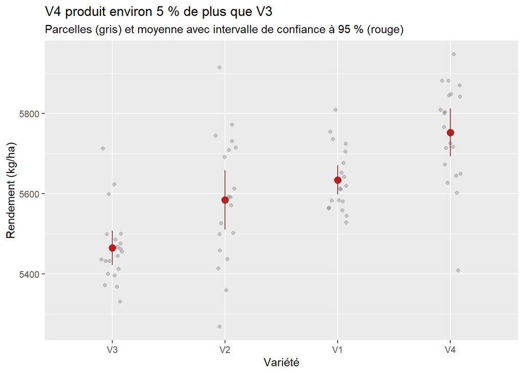

```r
ggplot(ble, aes(x = fct_reorder(variete, rdt), y = rdt)) +
  geom_jitter(width = 0.1, alpha = 0.3, colour = "grey40") +
  stat_summary(fun.data = mean_cl_normal, colour = "firebrick", size = 0.6) +
  labs(x = "Variété", y = "Rendement (kg/ha)",
       title = "V4 produit environ 5 % de plus que V3",
       subtitle = "Parcelles (gris) et moyenne avec intervalle de confiance à 95 % (rouge)")
```

Plutôt que des barres, on représente les moyennes par des points avec leur intervalle de confiance, superposés aux parcelles individuelles. Un point n’est pas lu comme une longueur, l’axe n’a donc pas besoin de partir de 0 : on peut zoomer sans tromper. Les observations et les intervalles donnent l’échelle de la variabilité, ce qui permet de juger si l’écart entre variétés est important par rapport aux différences entre parcelles, et le titre donne l’écart en pourcentage.